# ICB Plots

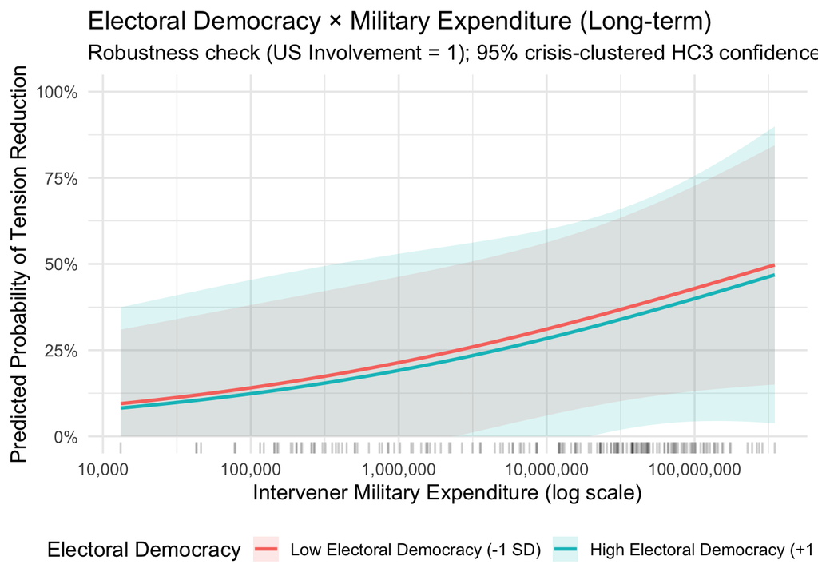

H1.10 Transparency * Military Expenditure

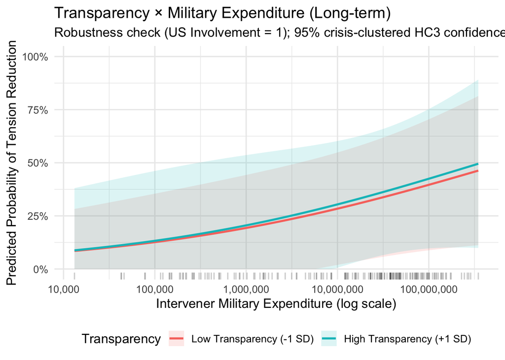

H1.11 Electoral Democracy * Ties to Both Sides

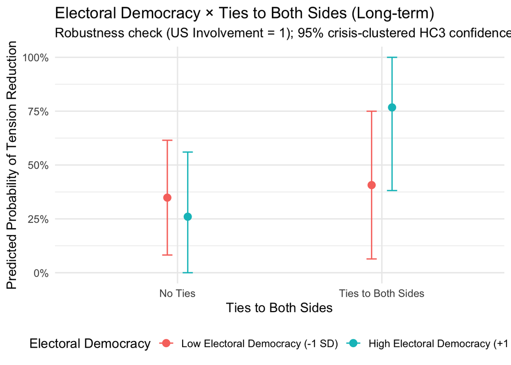

H1.12 Transparency * Ties to Both Sides

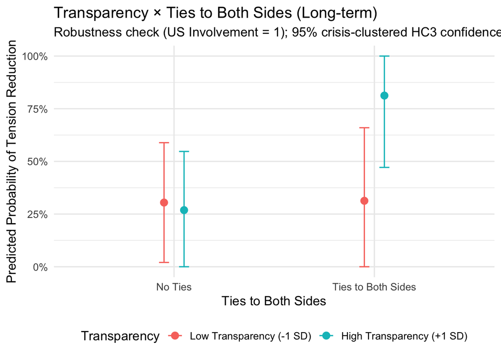

## Short-term Results

H2.1 Regime Type

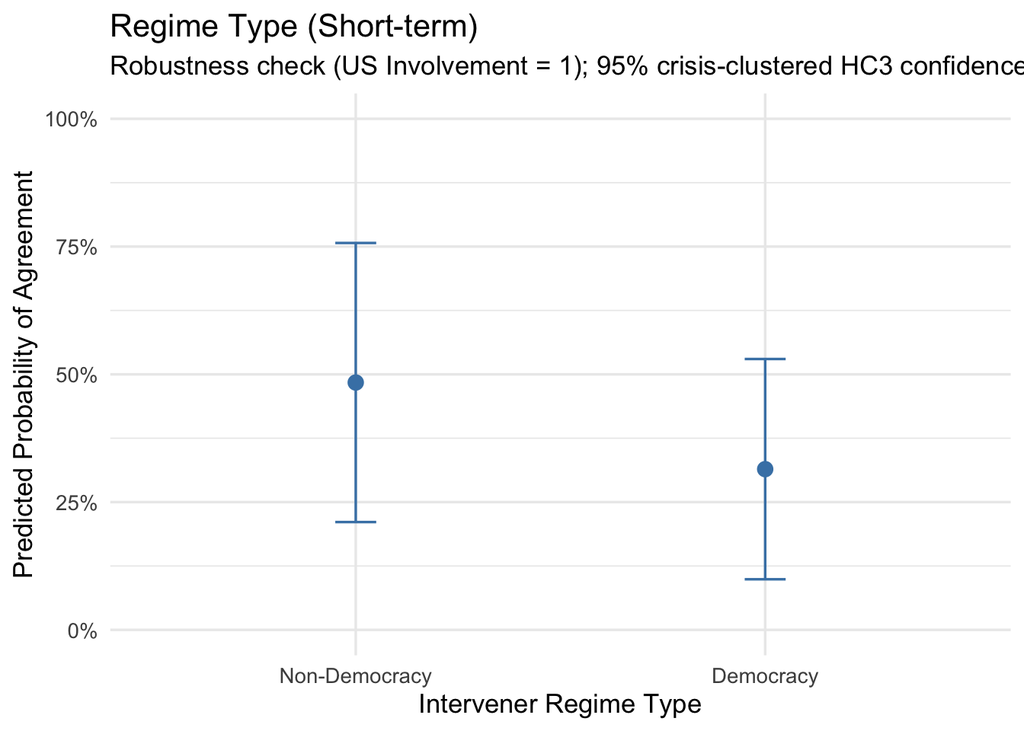

H2.2 Personalism

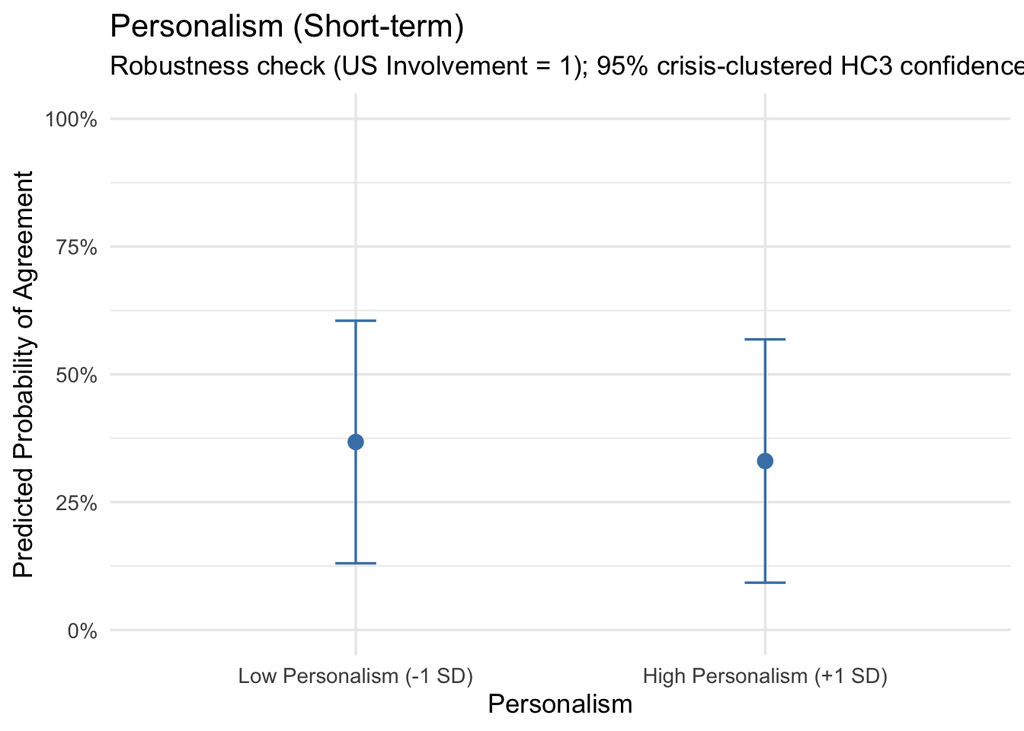

H2.3 Regime type × Military expenditure

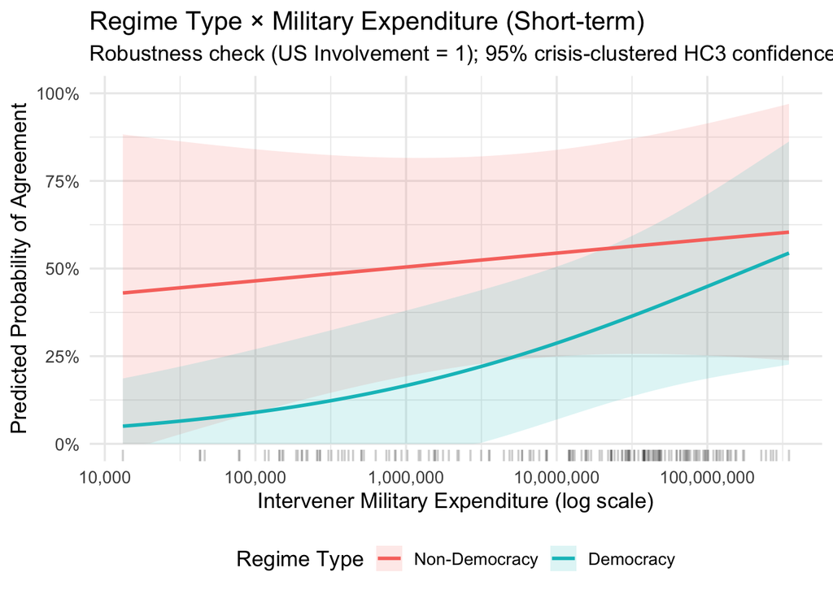

H2.4 Personalism × Military expenditure

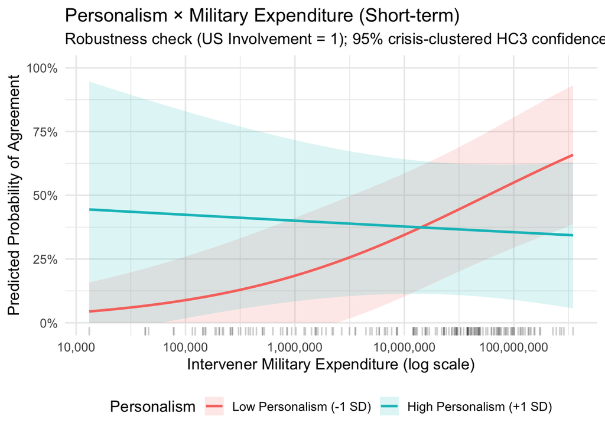

H2.5 Regime Type * Ties to Both Sides

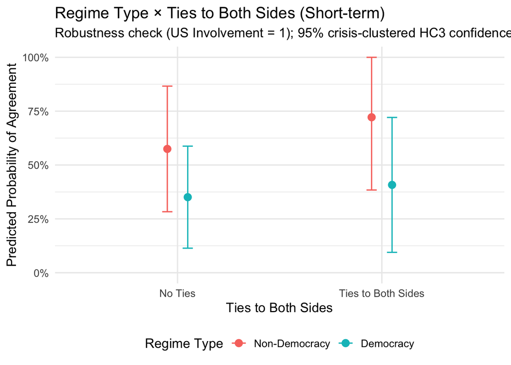

H2.6 Personalism × Ties to both sides

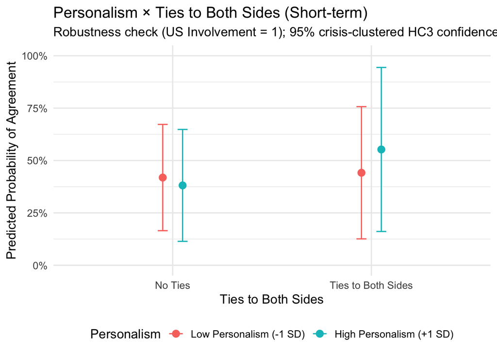

H2.7 Human Rights * Ties to Both Sides

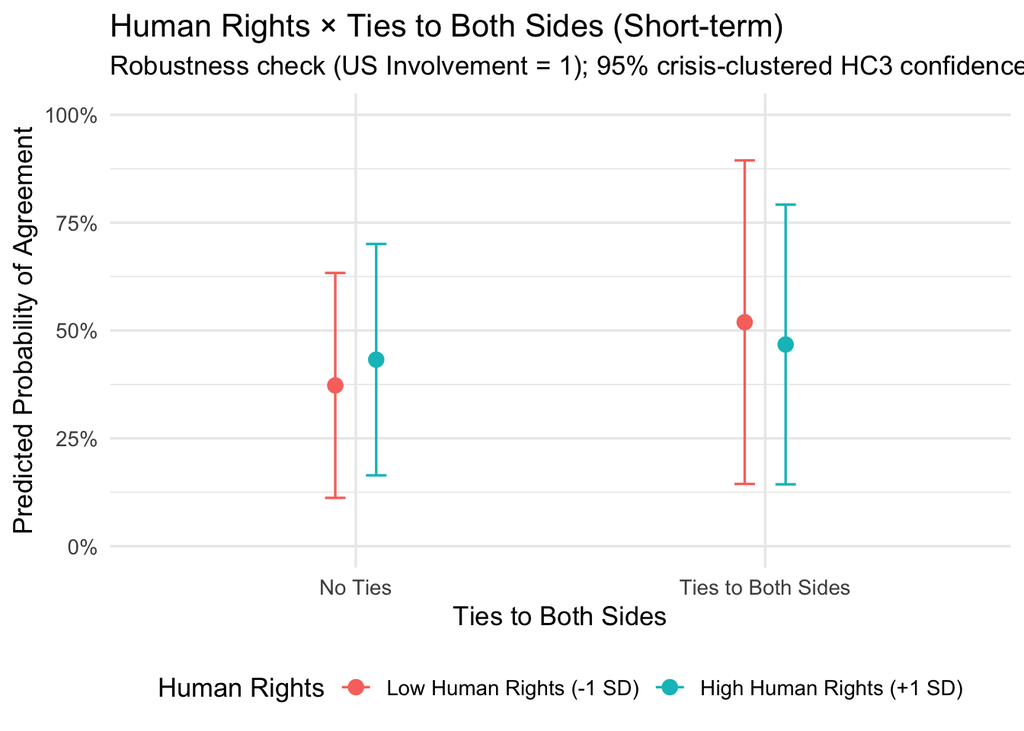

H2.8 Human Rights * Military Expenditure

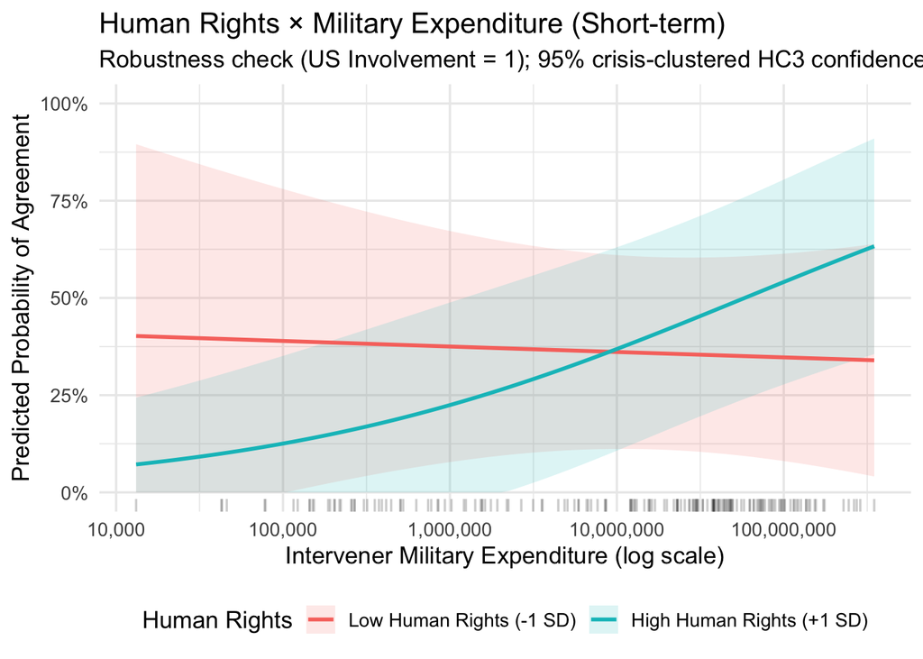

H2.9 Electoral Democracy * Military Expenditure

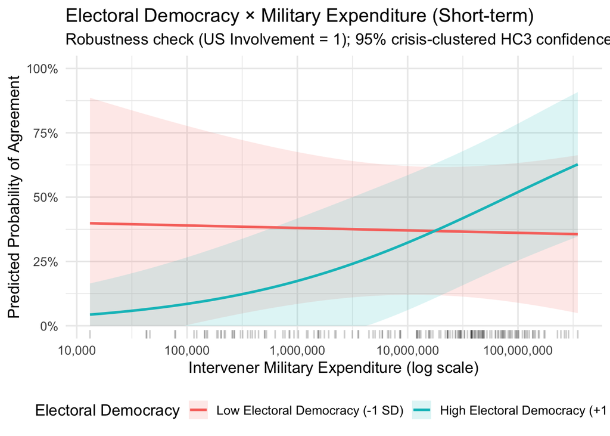

H2.10 Transparency * Military Expenditure

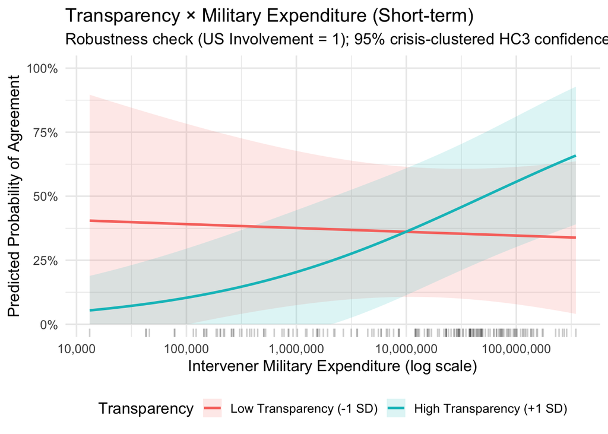

H2.11 Electoral Demo * Ties to Both Sides

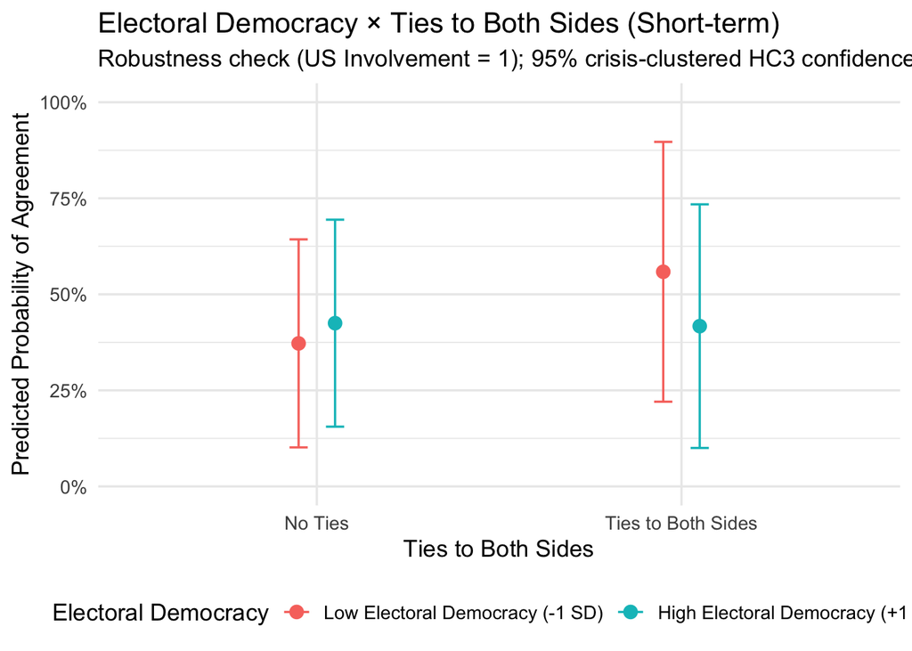

H2.12 Transparency * Ties to Both Sides

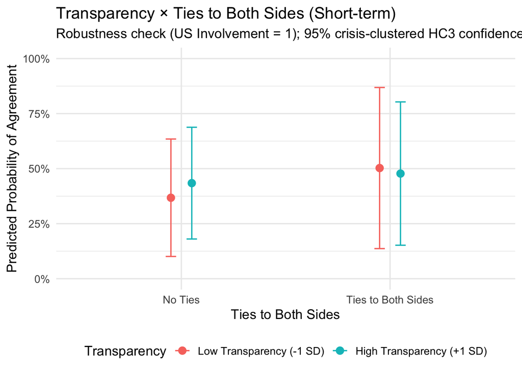

# Export: Core Finding Plots

# Export: Other Plots